# Classification of fitness activity

Vuk W

August 20, 2015

A group of enthusiasts recorded they fitness activity and classified it into 5 manners. The goal of this project is to find a patterns in their behavior and classify new examples into one of types.

# Content

1. preparing environment (libraries)
2. reading raw values
3. preparing data for analysis
4. splitting data into train / validation sets
5. training model on train set
6. estimating out-of-bag error on train and validation sets
7. predicting new values on test set and writing down the answers
8. conclusion

## 1. Libraries

For analysis we’’ll use caret library that provides a lot of instruments for pedicting / splitting etc

```r
library(caret)
```

```r
library(ggplot2)
```

## 2. reading raw values

```r
set.seed(514229)
nastr <- c("NA", "#DIV/0!","")
trainingRaw<-read.csv("pml-training.csv", na.strings = nastr)
testingRaw<-read.csv("pml-testing.csv" , na.strings = nastr)
dim(trainingRaw)
```

```
## [1] 19622   160
```

## 3. Preparing data for analysis

I’ll not provide summary for raw training set because of its huge number of columns, but it could be easily seen that whole dataset could be splitted into two parts:  
-part with field “new_window” == “yes”, with almost all columns fulfilled;  
-part with field “new_window” == “no”, with 101 columns empty.

In my opinion, such data should be analysed separately with different approaches and maybe different models. But raw test set has only values with “new_window” == “no”, thus we will build only this model and leave first part of data out of here.

```r
n<-ncol(trainingRaw)
#retaining only not-new-window data
emptystrs<-trainingRaw$new_window == "no"
emptytrain<-trainingRaw[emptystrs,]
emptycols<-NULL
#go through all columns and drop columns with 0 or 1 different values
for (i in 1:n){

  if (is.factor(emptytrain[,i])){
    emptytrain[,i]<-droplevels(emptytrain[,i])
  }
  if (length(levels(as.factor(emptytrain[,i])))<=1){
    emptycols<-c(emptycols,i)
  }
}
head(training[,1:7])
```

```
##   X user_name raw_timestamp_part_1 raw_timestamp_part_2   cvtd_timestamp
## 1 1  carlitos           1323084231               788290 05/12/2011 11:23
## 2 2  carlitos           1323084231               808298 05/12/2011 11:23
## 3 3  carlitos           1323084231               820366 05/12/2011 11:23
## 4 4  carlitos           1323084232               120339 05/12/2011 11:23
## 5 5  carlitos           1323084232               196328 05/12/2011 11:23
## 6 6  carlitos           1323084232               304277 05/12/2011 11:23
##   new_window num_window
## 1         no         11
## 2         no         11
## 3         no         11
## 4         no         12
## 5         no         12
## 6         no         12
```

Also first seven columns of training set have values that we can receive only in training but not in real life. They are higly correlated with result activity class:

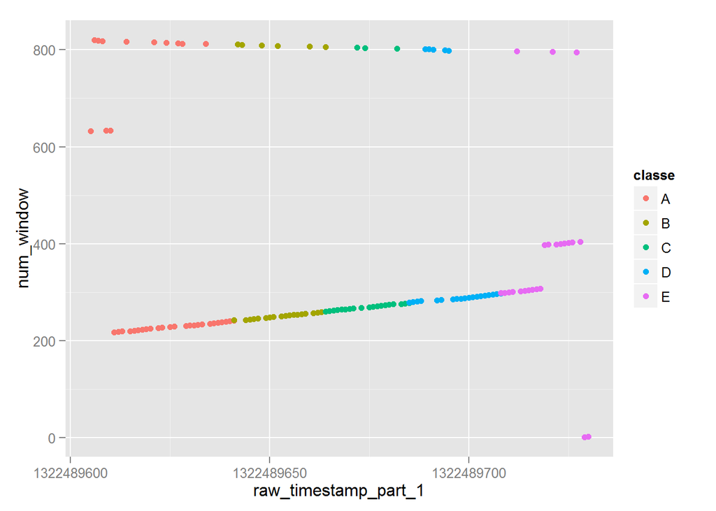

```r
qplot(raw_timestamp_part_1,num_window, color = classe, data = training[(training$new_window == "no")&(training$raw_timestamp_part_1 < 1322600000),])
```

We will exclude such columns from analysis too.

```r
#add to emptycols some experiment variables
emptycols<-c(emptycols, 1:7)
```

And eventually we get a grid with data readly for predicting:

```r
emptytrain<-emptytrain[,-emptycols]
emptytest<-testing[,-emptycols]
emptytest<-emptytest[,-ncol(emptytest)]
colnames(emptytrain)
```

```
##  [1] "roll_belt"            "pitch_belt"           "yaw_belt"
##  [4] "total_accel_belt"     "gyros_belt_x"         "gyros_belt_y"
##  [7] "gyros_belt_z"         "accel_belt_x"         "accel_belt_y"
## [10] "accel_belt_z"         "magnet_belt_x"        "magnet_belt_y"
## [13] "magnet_belt_z"        "roll_arm"             "pitch_arm"
## [16] "yaw_arm"              "total_accel_arm"      "gyros_arm_x"
## [19] "gyros_arm_y"          "gyros_arm_z"          "accel_arm_x"
## [22] "accel_arm_y"          "accel_arm_z"          "magnet_arm_x"
## [25] "magnet_arm_y"         "magnet_arm_z"         "roll_dumbbell"
## [28] "pitch_dumbbell"       "yaw_dumbbell"         "total_accel_dumbbell"
## [31] "gyros_dumbbell_x"     "gyros_dumbbell_y"     "gyros_dumbbell_z"
## [34] "accel_dumbbell_x"     "accel_dumbbell_y"     "accel_dumbbell_z"
## [37] "magnet_dumbbell_x"    "magnet_dumbbell_y"    "magnet_dumbbell_z"
## [40] "roll_forearm"         "pitch_forearm"        "yaw_forearm"
## [43] "total_accel_forearm"  "gyros_forearm_x"      "gyros_forearm_y"
## [46] "gyros_forearm_z"      "accel_forearm_x"      "accel_forearm_y"
## [49] "accel_forearm_z"      "magnet_forearm_x"     "magnet_forearm_y"
## [52] "magnet_forearm_z"     "classe"
```

## 4. splitting raw train data into train and validation sets

```r
trainId<-createDataPartition(emptytrain$classe, p = 0.8, list = F)
emptyval<-emptytrain[-trainId,]
emptytrain<-emptytrain[trainId,]
```

## 5. Training model

In order to predict new values of classe we will train random forest model. As a metrics for training we will use out-of-bag error. Usually metrics error on training dataset is lower limit for error on real data.

```r
trmod<-NULL
trmod<-train(classe~., data = emptytrain, method = "rf", trControl = trainControl(method = "oob"))
trmod$finalModel
```

```
##
## Call:
##  randomForest(x = x, y = y, mtry = param$mtry)
##                Type of random forest: classification
##                      Number of trees: 500
## No. of variables tried at each split: 27
##
##         OOB estimate of  error rate: 0.59%
## Confusion matrix:
##      A    B    C    D    E class.error
## A 4369    4    1    1    2 0.001827736
## B   19 2949    6    1    0 0.008739496
## C    0   10 2663    9    0 0.007084265
## D    0    1   23 2492    2 0.010325655
## E    0    1    5    6 2811 0.004250797
```

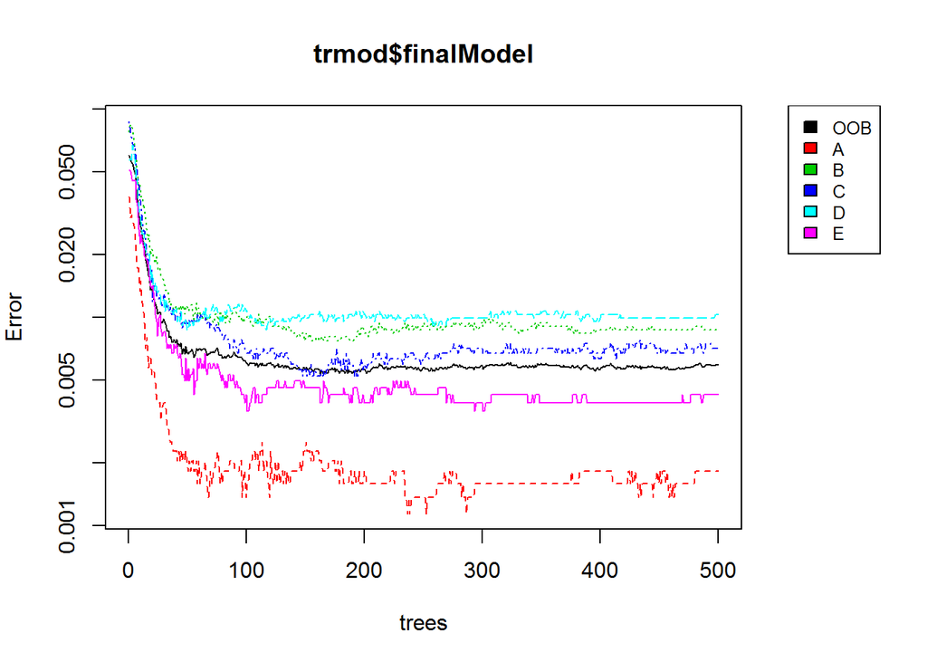

```r
layout(matrix(c(1,2),nrow=1), width=c(4,1))
par(mar=c(5,4,4,0)) #No margin on the right side
plot(trmod$finalModel, log="y")
par(mar=c(5,0,4,0)) #No margin on the left side
plot(c(0,1),type="n", axes=F, xlab="", ylab="")
legend("top", colnames(trmod$finalModel$err.rate),col=1:6,cex=0.8,fill=1:6)
```

## 6. Estimating out-of-bag error rate

```r
#column number for observed validation class
ny<-ncol(emptyval)
conf<-confusionMatrix(emptyval$classe, predict(trmod, emptyval[,-ny]))
conf$table
```

```
##           Reference
## Prediction    A    B    C    D    E
##          A 1094    0    0    0    0
##          B    1  741    1    0    0
##          C    0    3  664    3    0
##          D    0    0    7  620    2
##          E    0    0    3    2  700
```

```r
conf$overall["Accuracy"]
```

```
##  Accuracy
## 0.9942723
```

```r
val_error <- 1-conf$overall["Accuracy"]
names(val_error)<-NULL
val_error
```

```
## [1] 0.005727675
```

As we can see, estimated OOB error is lying between 0.0035929 and 0.008659 with p-value 95%.

## 7. prediction on the testset

```r
answers<-predict(trmod,emptytest)
n = length(answers)
for(i in 1:n){
  filename = paste0("problem_id_",i,".txt")
  write.table(answers[i],file=filename,quote=FALSE,row.names=FALSE,col.names=FALSE)
}
```

## 8. Conclusion

```r
vi<-varImp(trmod$finalModel)
vi$varnames<-rownames(vi)
rownames(vi)<-NULL
head(vi[order(vi$Overall, decreasing = T),],10)
```

```
##      Overall          varnames
## 1  1565.4461         roll_belt
## 41  946.2780     pitch_forearm
## 3   872.0458          yaw_belt
## 40  709.3666      roll_forearm
## 2   696.8077        pitch_belt
## 39  690.9388 magnet_dumbbell_z
## 38  687.0218 magnet_dumbbell_y
## 35  359.9286  accel_dumbbell_y
## 47  310.3431   accel_forearm_x
## 37  286.8825 magnet_dumbbell_x
```